# Luciana Quispe

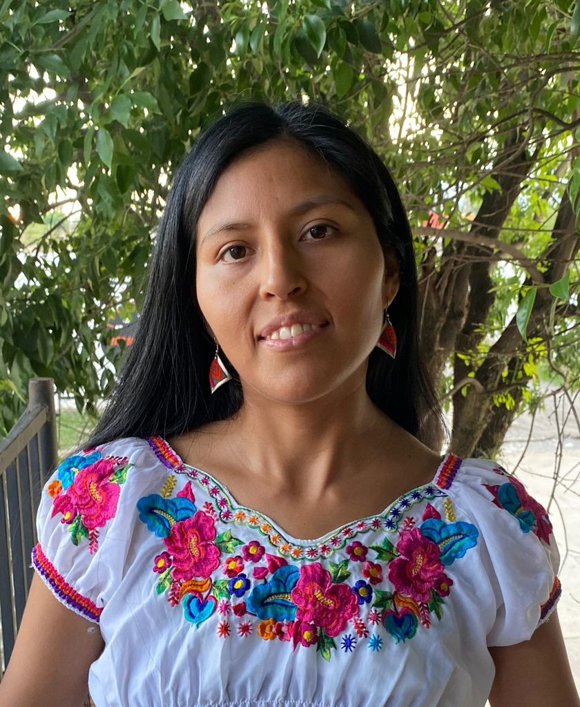

Luciana Quispe, indígena da etnia quéchua, é nascida na província de *Jujuy*, no extremo Norte da Argentina, em um pequeno povoado chamado de *Puesto del Marqués*. Por conta de seus avós serem ferroviários, sua relação e a de sua família com a cidade foi flexível, fazendo com que hoje ela também seja instalada em *San Salvador de Jujuy*, capital da província, tendo então uma dupla residência, tanto na capital quanto em seu povoado.

Luciana é graduada em Antropologia Social e Cultural pela Faculdade de Filosofia e Letras da Universidade de Buenos Aires (FFYL-UBA). Atualmente está cursando doutorado em Ciências Antropológicas com uma bolsa do *Consejo Nacional de Investigaciones Científicas y Técnicas* (CONICET) e também estudou cinema, buscando um aliado no audiovisual, visto que muitos povos indígenas não utilizam a escrita como método de estudo e transmissão de conhecimentos, na *Escuela Nacional de Experimentación y Realización Cinematográfica* (ENERC).

Além de todo seu currículo acadêmico, Luciana faz parte da comunidade indígena *quechua-aymara “Qhapajñán”*, onde é ativista. Seu principal interesse é em tornar as pesquisas antropológicas mais diversas e incluir voz aos povos indígenas, buscando mesclar a academia com o território. Ela possui diversos trabalhos publicados sobre as temáticas referentes.

## Povo Quéchua

Os povos Quéchua (também denominados *kichwa, ingas, runakuna’ ou nunakuna*) são originários da região da Cordilheira dos Andes, no que hoje são os países como Equador, Colômbia, Peru, Bolívia, Argentina e Chile. Estima-se que sua população seja de 9 a 14 milhões de indivíduos. Esse grupo étnico-linguístico indígena possui um baixo senso de identidade comum, com diversos dialetos sendo tão distintos que são praticamente ininteligíveis entre si.

Acredita-se que a língua quéchua se dissemina pela região dos Andes Centrais no Período Intermediário Tardio, sendo uma das três grandes línguas do período e fortemente utilizada pelo *Tawantinsuyu*, ou Império Inca. Entretanto, sua existência é anterior à organização deste e persiste após sua queda e o início do processo de colonização. Sua língua é, até os dias atuais, uma das principais línguas indígenas do continente sulamericano.  
Os povos Quéchua, assim como outros povos da região dos Andes Centrais, organizam-se socialmente em *ayllus*, entidades sociais que envolvem o mundo humano e não-humano. Após a invasão espanhola e os séculos de conflitos, esses povos absorvem elementos da religião católica, também mantendo elementos de sua religiosidade como o culto aos *apus* (espíritos das montanhas) e à Mãe Terra, ou *Pachamama*, uma deidade tradicional da região. Sua cosmovisão, está expressa na *Pacha*, que significa em quéchua uma maneira de integralizar o espaço-tempo e a vida no cosmos, sem divisões como propõe a modernidade ocidental.

No cenário atual, esses povos vivem ainda uma marginalização social e, em casos como a Argentina, um apagamento e não reconhecimento de sua existência e direitos. Na Bolívia e no Peru, a língua quéchua é reconhecida como oficial, sendo ensinada em escolas em algumas regiões de ambos os países. Além disso, na Bolívia está localizada a *Universidad Indígena Boliviana Quechua “Casimiro Huanca”*, que responde a necessidade de disponibilizar acesso a jovens quéchua que são marginalizados. Dessa forma, é configurado um espaço que permite a disseminação do conhecimento, para que os ensinamentos ancestrais dos povos quéchua se mantenha forte.

Entretanto, o território e estilo de vida desses povos ainda é violado, como mostra o caso de vazamento de petróleo ocorrido no Peru ao final de 2024 que afetou 10 aldeias do povo Quéchua. Em outubro do ano passado, mais um crime ambiental cometido pela *PetroPerú*, companhia petrolífera estatal do Peru, acometeu diversas comunidades indígenas, dentre elas os Quéchua. Desde sua construção há 50 anos, esses povos são afetados pelas práticas criminosas da empresa, e desta vez com um novo vazamento que não foi contido a tempo, fluxos fluviais tiveram seu curso extremamente contaminado, transformando a dinâmica de sobrevivência dessas comunidades indígenas. O povo Quéchua, em conjunto com outras etnias, lutam a anos para que a estatal seja responsabilizada por todos os seus crimes, que de forma irreversível causam danos às estruturas e bases da fauna e da flora, essas duas que são a fonte motriz dos povos indígenas.

**Texto elaborado por Gabriel Constantino Pellegrino Biasoli e Victor de Carvalho Cunha**

Ouça a entrevista completa:

[figure not shown]

[figure not shown]

[figure not shown]